# R_keras_Unet

Unet implementation in R flavor of Keras

## Semantic segmentation on aerial imagery

### Buildings

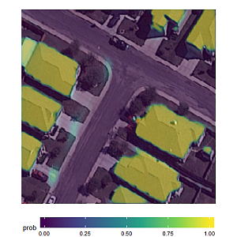

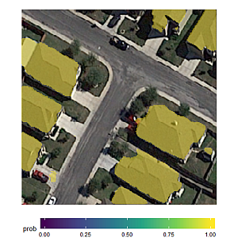

### Roads

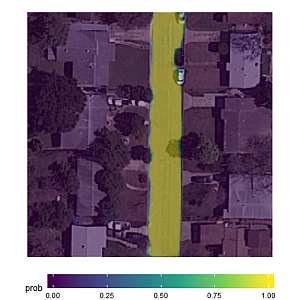

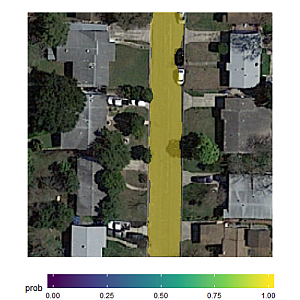

## infinite training chip generator

## on-the-fly image and mask augmentation

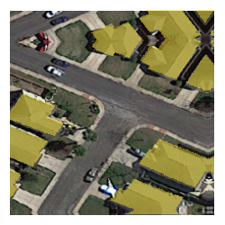

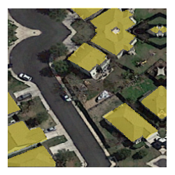

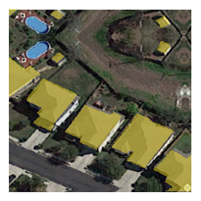

## TODO:

- somehow split out training image vs val image
  - add stride/padding/offset and train/val split values to config
  - add function to make all possible overlapping tile UL coords
  - split all-possible into train/val based on config value
  - only pull infinite chip from train list of possible UL corner coords
  - has to check to see if all-possble coords exist, but DOES NOT KNOW if you changed dim, need to make it aware
    - ran into this bug before b/c no notice of using old data. add message when ussing old data
  - add option to config to reser the all-possble train/val splits
  - has to be able to also function as it does now where split% == 0 so train/val randomly from same of seperate study area images
  - Alternative to random select of train/val set (best in Kfolds CV) is to have full train/val images or either seperate geographies or strips/sections/blocks of single geography where train is NA where Val has data.
- add functionality to record dice/jaccard by batch and chip coords to reconstruct error map
  - somehow write out coords form batch and then join to error metric of that batch.
- image normalization to dataset mean/variance (in config)
- Test additional architectures
- Test Time Augmenting, flipping, mirror, etc… (large area prediction)
- Make it easy to test on different classes (still all binary class prediction)

## Info/Sources

- Rstudio Keras example repo of Unet
  - https://github.com/rstudio/keras/blob/master/vignettes/examples/unet.R
- Augment images and masks
  - https://github.com/keras-team/keras/issues/3059
  - https://keras.io/preprocessing/image/
  - https://github.com/rstudio/keras/blob/707427fa1f8e192e662b209e63fb962e99ba8fbf/vignettes/examples/cifar10_cnn.R
  - https://keras.rstudio.com/reference/image_data_generator.html